# R Notebook: Descriptive Stats and Visuals

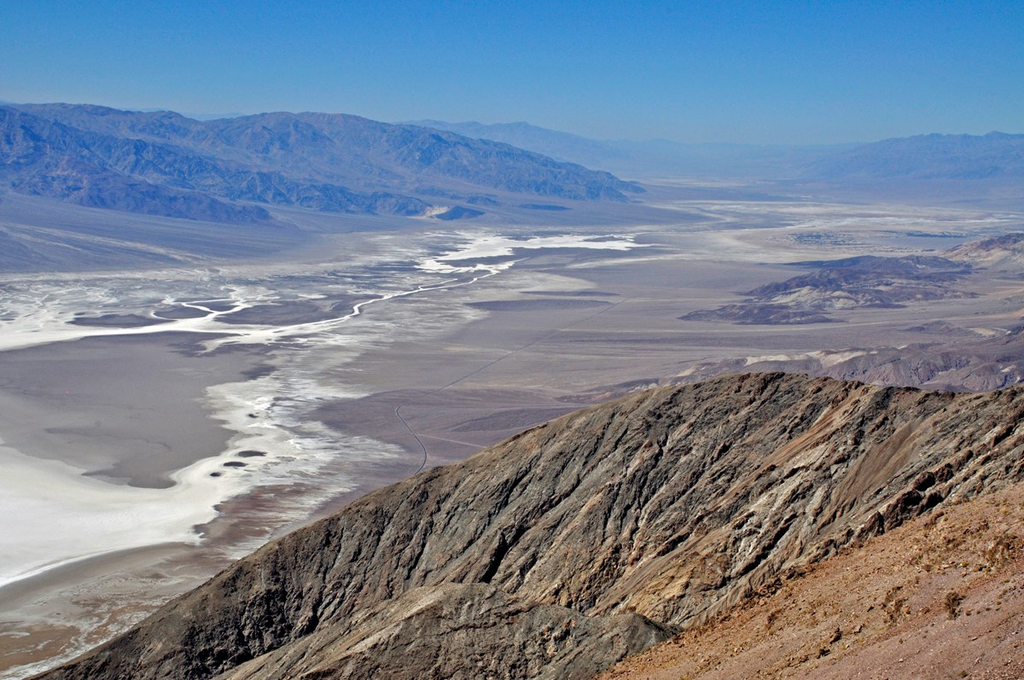

Dante’s View in Death Valley National Park

Data for this example comes from [the USGS](https://earthquake.usgs.gov/earthquakes/feed/v1.0/csv.php)

```r
getwd()
```

```
## [1] "C:/Users/User/Documents/R/USGSquakes"
```

Lets load the data in from a CSV file

```r
quakes <- read.csv("all_month.csv")
```

now lets take a look at the table to start

```r
head(quakes)
```

|  | time | latitude | longitude | depth | mag | magType | nst | gap | dmin | rms | net | id | updated | place | type | horizontalError | depthError | magError | magNst | status | locationSource | magSource |
| --- | --- | --- | --- | --- | --- | --- | --- | --- | --- | --- | --- | --- | --- | --- | --- | --- | --- | --- | --- | --- | --- | --- |
| 1 | 2018-01-31T23:13:21.590Z | -1.75590 | -77.6944 | 18.66 | 5.20 | mb | NA | 28.00 | 1.20300 | 0.9300 | us | us1000cdgu | 2018-01-31T23:38:10.977Z | 27km ESE of Palora, Ecuador | earthquake | 4.80 | 4.20 | 0.024 | 560 | reviewed | us | us |
| 2 | 2018-01-31T23:00:09.830Z | 35.46433 | -115.5348 | -1.14 | 1.75 | ml | 12 | 168.00 | 0.02496 | 0.1200 | ci | ci38096248 | 2018-01-31T23:40:07.543Z | 21km SW of Primm, NV | quarry blast | 0.34 | 31.61 | 0.199 | 11 | reviewed | ci | ci |
| 3 | 2018-01-31T22:52:28.590Z | 61.26510 | -147.6514 | 19.60 | 1.60 | ml | NA | NA | NA | 1.1200 | ak | ak18263191 | 2018-01-31T22:58:15.323Z | 71km WNW of Valdez, Alaska | earthquake | NA | 0.50 | NA | NA | automatic | ak | ak |
| 4 | 2018-01-31T22:41:08.878Z | 39.70790 | -120.3486 | 11.30 | 0.60 | ml | 18 | 100.35 | 0.09100 | 0.1883 | nn | nn00620278 | 2018-01-31T22:56:49.976Z | 15km SE of Portola, California | earthquake | NA | 1.80 | 0.440 | 4 | reviewed | nn | nn |
| 5 | 2018-01-31T22:12:23.084Z | 36.71610 | -116.2556 | 0.00 | -0.10 | ml | 6 | 176.13 | 0.03700 | 0.2109 | nn | nn00620277 | 2018-01-31T22:41:14.968Z | 49km ESE of Beatty, Nevada | earthquake | NA | 0.00 | 0.010 | 2 | reviewed | nn | nn |
| 6 | 2018-01-31T22:11:37.503Z | 39.82530 | -120.7783 | 8.70 | 0.90 | ml | 10 | 95.09 | 0.08600 | 0.1593 | nn | nn00620274 | 2018-01-31T22:37:59.127Z | 15km SE of East Quincy, California | earthquake | NA | 3.60 | 0.000 | 2 | reviewed | nn | nn |

now we will go in and do summary statistics on “mag”

```r
summary(quakes$mag)
```

```
##    Min. 1st Qu.  Median    Mean 3rd Qu.    Max.    NA's
##  -0.820   0.730   1.300   1.585   2.000   7.900       1
```

```r
sd(quakes$mag, na.rm=TRUE)
```

```
## [1] 1.23015
```

Now lets look at a simple histogram of the magnitude

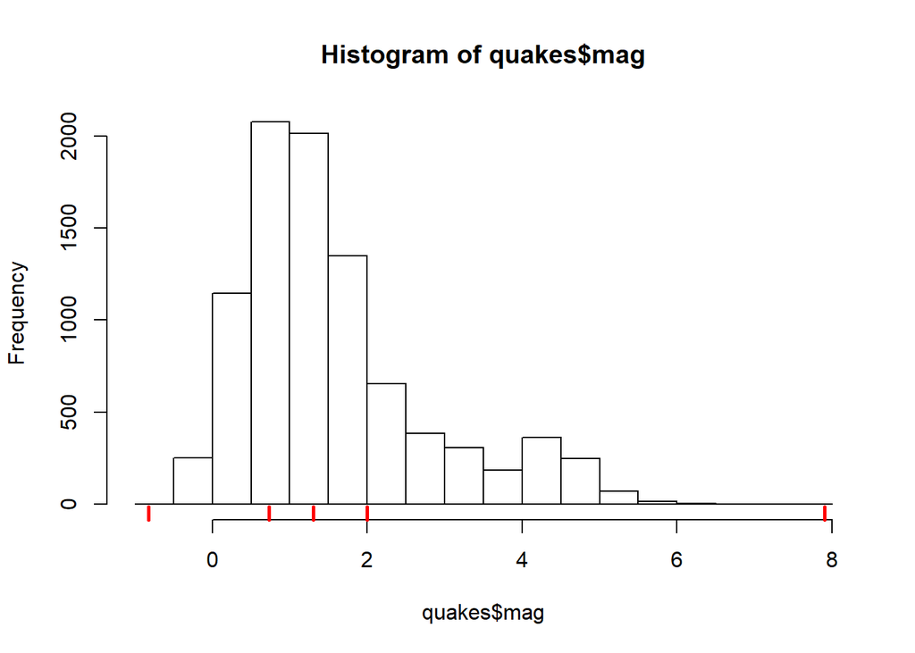

```r
hist(quakes$mag)
rug(quantile(quakes$mag, na.rm = TRUE), col=2, lwd=2.5)
```

lets get the quartile values

```r
quantile(quakes$mag, probs = c(0, 0.25, 0.5, 0.75, 1), na.rm = TRUE)
```

```
##    0%   25%   50%   75%  100%
## -0.82  0.73  1.30  2.00  7.90
```

Now lets look at the normal qq plot of this same data, another way to look at distribution

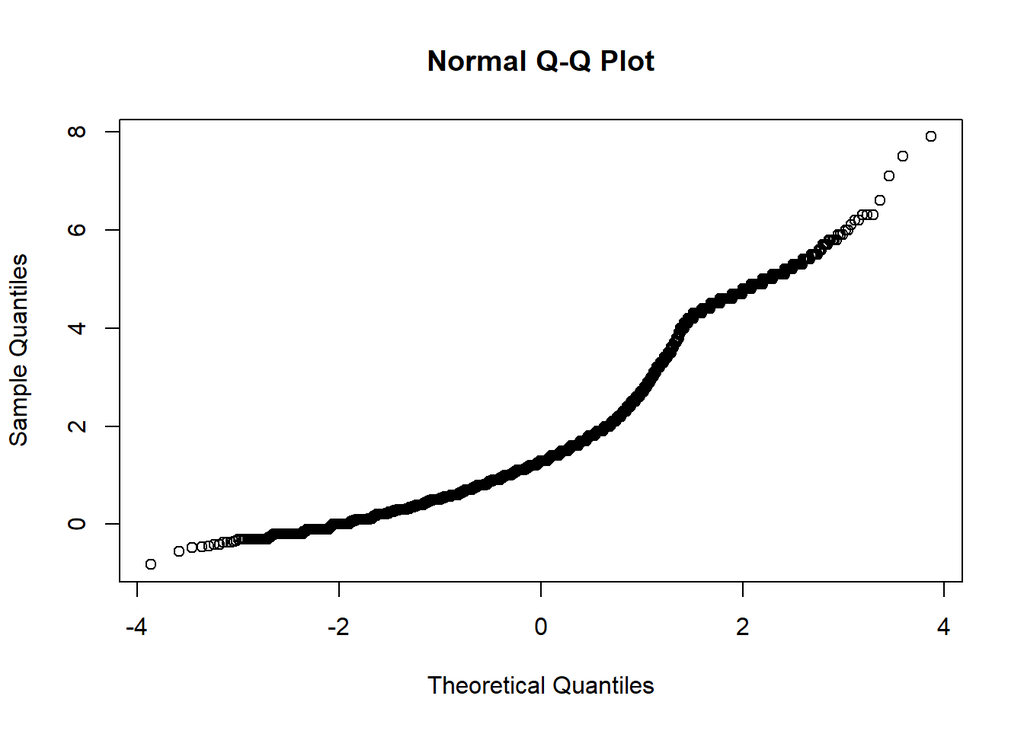

```r
qqnorm(quakes$mag)
```

Now lets look at the depth with the same plots

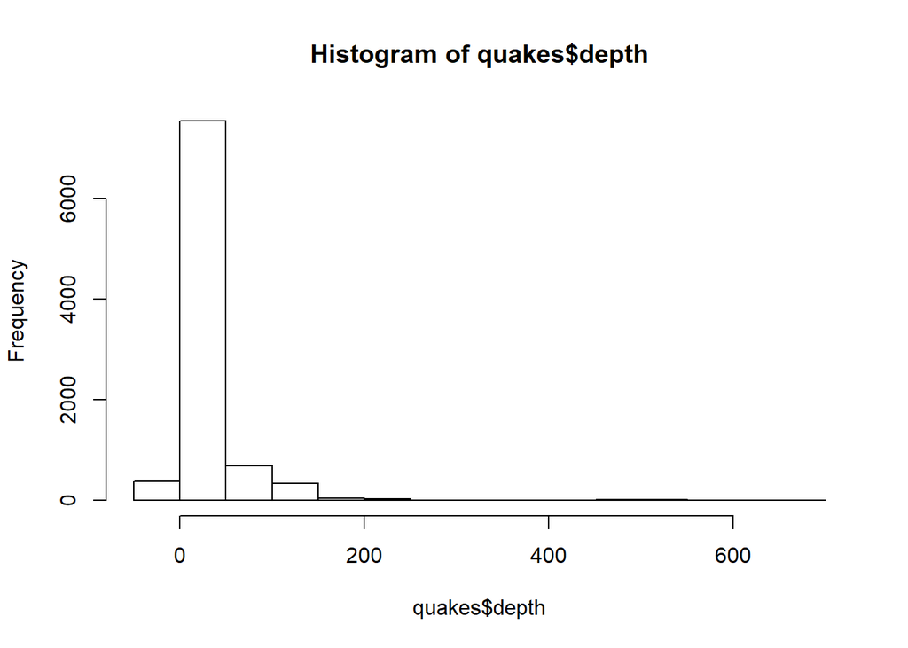

```r
hist(quakes$depth)
```

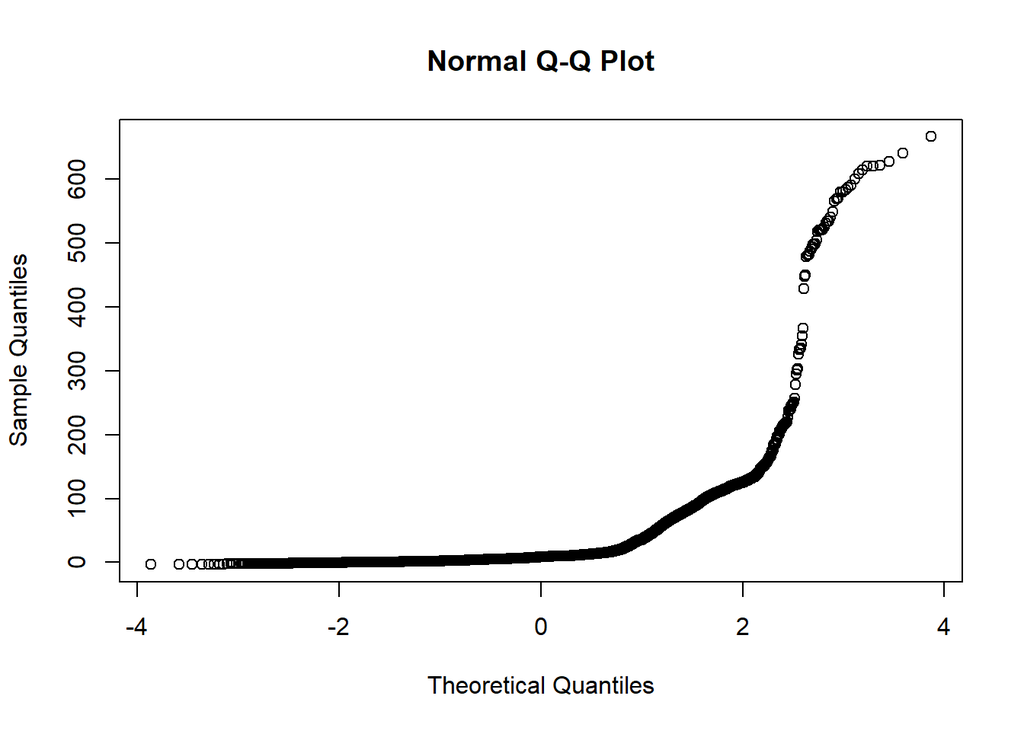

```r
qqnorm(quakes$depth)
```

now lets look at a scatter plot magnitude vs. depth

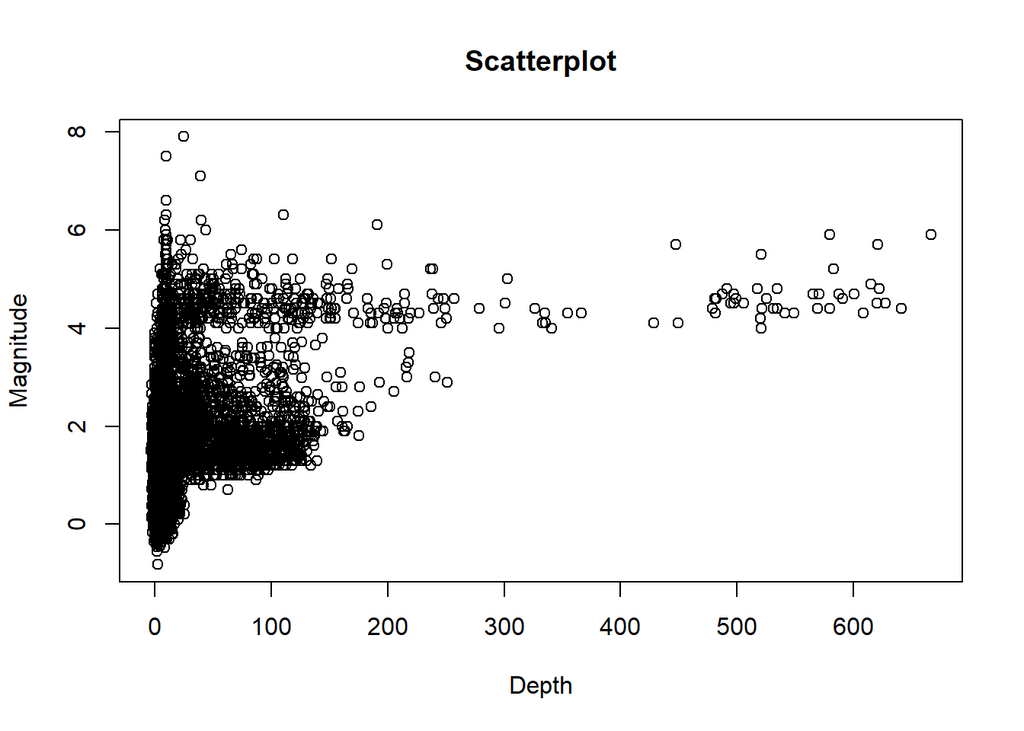

```r
plot(quakes$depth, quakes$mag, main="Scatterplot",
     xlab="Depth", ylab="Magnitude")
```

Lets to box plots of depts by magnitude but first we cut the continuous value of magnitude into bins

```r
quakes$maggroup <- round(quakes$mag,digits=0)
head(quakes)
```

|  | time | latitude | longitude | depth | mag | magType | nst | gap | dmin | rms | net | id | updated | place | type | horizontalError | depthError | magError | magNst | status | locationSource | magSource | maggroup |
| --- | --- | --- | --- | --- | --- | --- | --- | --- | --- | --- | --- | --- | --- | --- | --- | --- | --- | --- | --- | --- | --- | --- | --- |
| 1 | 2018-01-31T23:13:21.590Z | -1.75590 | -77.6944 | 18.66 | 5.20 | mb | NA | 28.00 | 1.20300 | 0.9300 | us | us1000cdgu | 2018-01-31T23:38:10.977Z | 27km ESE of Palora, Ecuador | earthquake | 4.80 | 4.20 | 0.024 | 560 | reviewed | us | us | 5 |
| 2 | 2018-01-31T23:00:09.830Z | 35.46433 | -115.5348 | -1.14 | 1.75 | ml | 12 | 168.00 | 0.02496 | 0.1200 | ci | ci38096248 | 2018-01-31T23:40:07.543Z | 21km SW of Primm, NV | quarry blast | 0.34 | 31.61 | 0.199 | 11 | reviewed | ci | ci | 2 |
| 3 | 2018-01-31T22:52:28.590Z | 61.26510 | -147.6514 | 19.60 | 1.60 | ml | NA | NA | NA | 1.1200 | ak | ak18263191 | 2018-01-31T22:58:15.323Z | 71km WNW of Valdez, Alaska | earthquake | NA | 0.50 | NA | NA | automatic | ak | ak | 2 |
| 4 | 2018-01-31T22:41:08.878Z | 39.70790 | -120.3486 | 11.30 | 0.60 | ml | 18 | 100.35 | 0.09100 | 0.1883 | nn | nn00620278 | 2018-01-31T22:56:49.976Z | 15km SE of Portola, California | earthquake | NA | 1.80 | 0.440 | 4 | reviewed | nn | nn | 1 |
| 5 | 2018-01-31T22:12:23.084Z | 36.71610 | -116.2556 | 0.00 | -0.10 | ml | 6 | 176.13 | 0.03700 | 0.2109 | nn | nn00620277 | 2018-01-31T22:41:14.968Z | 49km ESE of Beatty, Nevada | earthquake | NA | 0.00 | 0.010 | 2 | reviewed | nn | nn | 0 |
| 6 | 2018-01-31T22:11:37.503Z | 39.82530 | -120.7783 | 8.70 | 0.90 | ml | 10 | 95.09 | 0.08600 | 0.1593 | nn | nn00620274 | 2018-01-31T22:37:59.127Z | 15km SE of East Quincy, California | earthquake | NA | 3.60 | 0.000 | 2 | reviewed | nn | nn | 1 |

Now we’ll do boxplots

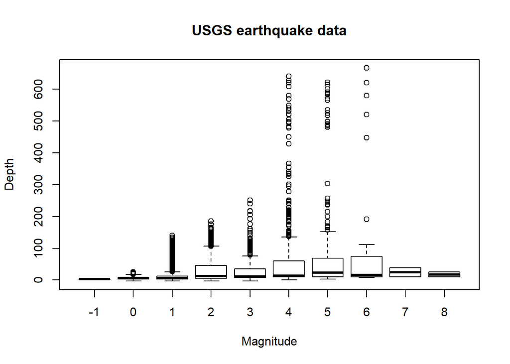

```r
boxplot(depth~maggroup, data=quakes, main="USGS earthquake data",
        xlab="Magnitude", ylab="Depth")
```

So we see a lot of outliers showing up in the magnitude 4 and 5 ranges

Lets now calculate the standard deviation values for each of the magnitude values

```r
quakes$MagStdDev = ((quakes$mag - 1.585)/1.23015)
head(quakes)
```

|  | time | latitude | longitude | depth | mag | magType | nst | gap | dmin | rms | net | id | updated | place | type | horizontalError | depthError | magError | magNst | status | locationSource | magSource | maggroup | MagStdDev |
| --- | --- | --- | --- | --- | --- | --- | --- | --- | --- | --- | --- | --- | --- | --- | --- | --- | --- | --- | --- | --- | --- | --- | --- | --- |
| 1 | 2018-01-31T23:13:21.590Z | -1.75590 | -77.6944 | 18.66 | 5.20 | mb | NA | 28.00 | 1.20300 | 0.9300 | us | us1000cdgu | 2018-01-31T23:38:10.977Z | 27km ESE of Palora, Ecuador | earthquake | 4.80 | 4.20 | 0.024 | 560 | reviewed | us | us | 5 | 2.93866602 |
| 2 | 2018-01-31T23:00:09.830Z | 35.46433 | -115.5348 | -1.14 | 1.75 | ml | 12 | 168.00 | 0.02496 | 0.1200 | ci | ci38096248 | 2018-01-31T23:40:07.543Z | 21km SW of Primm, NV | quarry blast | 0.34 | 31.61 | 0.199 | 11 | reviewed | ci | ci | 2 | 0.13412998 |
| 3 | 2018-01-31T22:52:28.590Z | 61.26510 | -147.6514 | 19.60 | 1.60 | ml | NA | NA | NA | 1.1200 | ak | ak18263191 | 2018-01-31T22:58:15.323Z | 71km WNW of Valdez, Alaska | earthquake | NA | 0.50 | NA | NA | automatic | ak | ak | 2 | 0.01219363 |
| 4 | 2018-01-31T22:41:08.878Z | 39.70790 | -120.3486 | 11.30 | 0.60 | ml | 18 | 100.35 | 0.09100 | 0.1883 | nn | nn00620278 | 2018-01-31T22:56:49.976Z | 15km SE of Portola, California | earthquake | NA | 1.80 | 0.440 | 4 | reviewed | nn | nn | 1 | -0.80071536 |
| 5 | 2018-01-31T22:12:23.084Z | 36.71610 | -116.2556 | 0.00 | -0.10 | ml | 6 | 176.13 | 0.03700 | 0.2109 | nn | nn00620277 | 2018-01-31T22:41:14.968Z | 49km ESE of Beatty, Nevada | earthquake | NA | 0.00 | 0.010 | 2 | reviewed | nn | nn | 0 | -1.36975166 |
| 6 | 2018-01-31T22:11:37.503Z | 39.82530 | -120.7783 | 8.70 | 0.90 | ml | 10 | 95.09 | 0.08600 | 0.1593 | nn | nn00620274 | 2018-01-31T22:37:59.127Z | 15km SE of East Quincy, California | earthquake | NA | 3.60 | 0.000 | 2 | reviewed | nn | nn | 1 | -0.55684266 |

Now lets get percentiles from that:

```r
quakes$magpcent = pnorm(quakes$MagStdDev)*100
head(quakes)
```

|  | time | latitude | longitude | depth | mag | magType | nst | gap | dmin | rms | net | id | updated | place | type | horizontalError | depthError | magError | magNst | status | locationSource | magSource | maggroup | MagStdDev | magpcent |
| --- | --- | --- | --- | --- | --- | --- | --- | --- | --- | --- | --- | --- | --- | --- | --- | --- | --- | --- | --- | --- | --- | --- | --- | --- | --- |
| 1 | 2018-01-31T23:13:21.590Z | -1.75590 | -77.6944 | 18.66 | 5.20 | mb | NA | 28.00 | 1.20300 | 0.9300 | us | us1000cdgu | 2018-01-31T23:38:10.977Z | 27km ESE of Palora, Ecuador | earthquake | 4.80 | 4.20 | 0.024 | 560 | reviewed | us | us | 5 | 2.93866602 | 99.835186 |
| 2 | 2018-01-31T23:00:09.830Z | 35.46433 | -115.5348 | -1.14 | 1.75 | ml | 12 | 168.00 | 0.02496 | 0.1200 | ci | ci38096248 | 2018-01-31T23:40:07.543Z | 21km SW of Primm, NV | quarry blast | 0.34 | 31.61 | 0.199 | 11 | reviewed | ci | ci | 2 | 0.13412998 | 55.335011 |
| 3 | 2018-01-31T22:52:28.590Z | 61.26510 | -147.6514 | 19.60 | 1.60 | ml | NA | NA | NA | 1.1200 | ak | ak18263191 | 2018-01-31T22:58:15.323Z | 71km WNW of Valdez, Alaska | earthquake | NA | 0.50 | NA | NA | automatic | ak | ak | 2 | 0.01219363 | 50.486444 |
| 4 | 2018-01-31T22:41:08.878Z | 39.70790 | -120.3486 | 11.30 | 0.60 | ml | 18 | 100.35 | 0.09100 | 0.1883 | nn | nn00620278 | 2018-01-31T22:56:49.976Z | 15km SE of Portola, California | earthquake | NA | 1.80 | 0.440 | 4 | reviewed | nn | nn | 1 | -0.80071536 | 21.164822 |
| 5 | 2018-01-31T22:12:23.084Z | 36.71610 | -116.2556 | 0.00 | -0.10 | ml | 6 | 176.13 | 0.03700 | 0.2109 | nn | nn00620277 | 2018-01-31T22:41:14.968Z | 49km ESE of Beatty, Nevada | earthquake | NA | 0.00 | 0.010 | 2 | reviewed | nn | nn | 0 | -1.36975166 | 8.538222 |
| 6 | 2018-01-31T22:11:37.503Z | 39.82530 | -120.7783 | 8.70 | 0.90 | ml | 10 | 95.09 | 0.08600 | 0.1593 | nn | nn00620274 | 2018-01-31T22:37:59.127Z | 15km SE of East Quincy, California | earthquake | NA | 3.60 | 0.000 | 2 | reviewed | nn | nn | 1 | -0.55684266 | 28.881747 |

Lets try a box plot of magnitude by reporting network

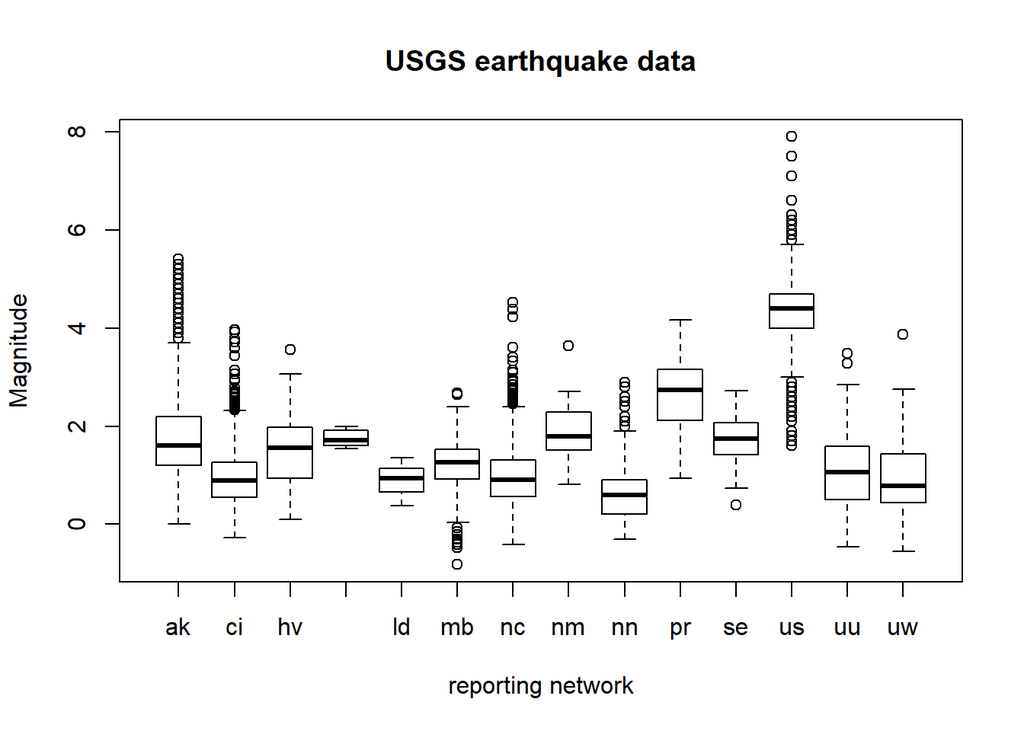

```r
boxplot(mag~net, data=quakes, main="USGS earthquake data",
        xlab="reporting network", ylab="Magnitude")
```